# R Notebook

Part 1 For each distribution below, generate a figure of the PDF and CDF. Mark the mean and median in the figure.

For each distribution below, generate a figure of the PDF and CDF of the transformation Y = log(X) random variable. Mark the mean and median in the figure. You may use simulation or analytic methods in order find the PDF and CDF of the transformation.

Distribution 1 X∼GAMMA(shape=3,scale=1)

Mean of a Gamma Distribution where Shape and Scale are the parameters used is given by : Mean = shape/scale There is no closed form for the median hence we use the empirical formula between mean, median and mode to calculate median : Median = (2*mean + mode)/3 where mode of a gamma distribution where Shape and Scale are the parameters used is given by Mode = (shape - 1)*scale where shape >= 1

Log of mean and median is taken in order to find out the mean and median of the log transformed respective distribution.

```r
shape = 3
scale = 1
mean = shape/scale
mode = (shape - 1)*scale
median = (2*mean + mode)/3
logmean = log(shape/scale)
logmedian = log(median)

#PDF
plot(dgamma(0:15, shape = shape, scale = scale), type = "l", xlab = "Value of Random Variable", ylab = "Probability", main = "PDF of Gamma Distribution")
abline(v = mean, col = "red")
```

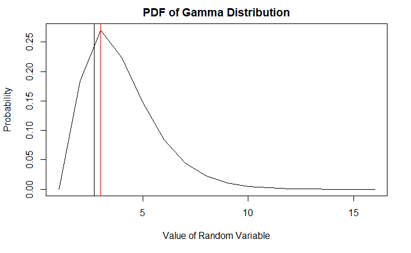

```r
abline(v = median, col = "black")
```

```r
#CDF
plot(pgamma(0:15, shape = 3, scale = 1), type = "l", xlab = "Value of Random Variable", ylab = "Probability", main = "CDF of Gamma Distribution")
abline(v = mean, col = "red")
```

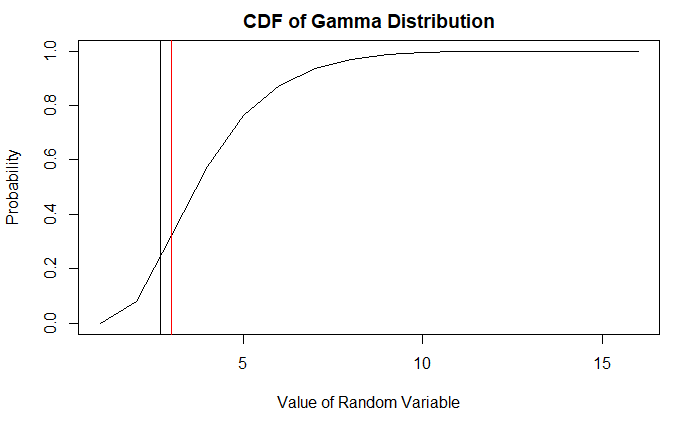

```r
abline(v = median, col = "black")
```

```r
#PDF of log(X)
plot(dgamma(0:15, shape = 3, scale = 1, log = TRUE), type = "l", xlab = "Value of Log of Random Variable", ylab = "Probability", main = "PDF of Gamma Distribution")
abline(v = logmean, col = "red")
```

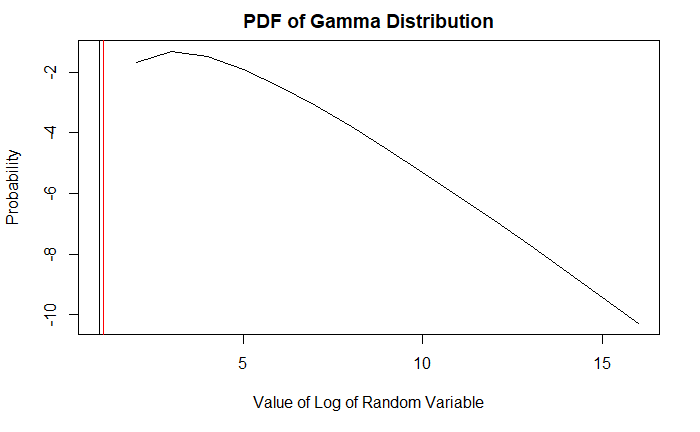

```r
abline(v = logmedian, col = "black")
```

```r
#CDF of log(X)
plot(log(pgamma(log(0:15), shape = 3, scale = 1)), type = "l", xlab = "Value of Log of Random Variable", ylab = "Probability", main = "CDF of Gamma Distribution")
abline(v = logmean, col = "red")
```

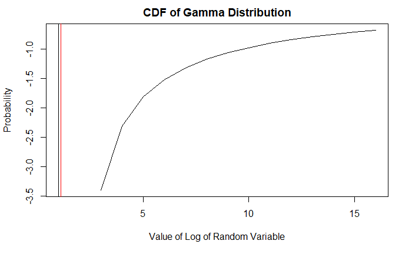

```r
abline(v = logmedian, col = "black")
```

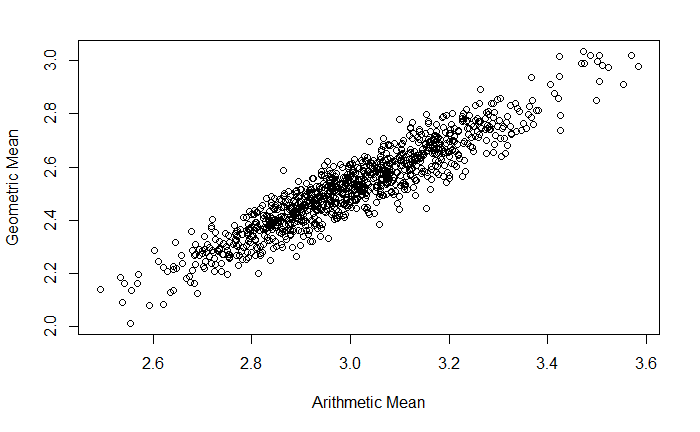

```r
mgamma = c()
gmgamma = c()
for (i in 1:1000)
{
  gamma <- rgamma(1:100, shape = 3, scale = 1)
  m <- mean(gamma)
  gm <- exp(mean(log(gamma)))
  mgamma[i] <- m
  gmgamma[i] <- gm
}

plot(mgamma, gmgamma, xlab = "Arithmetic Mean", ylab = "Geometric Mean")
```

Distribution 2 X∼LOG NORMAL(μ=−1,σ=1)

```r
meanlog = -1
sdlog = 1
meanln = exp(meanlog + (sdlog^2)/2)
medianln = exp(meanlog)
logmeanln = log(meanln)
logmedianln = log(medianln)

#PDF
plot(dlnorm(0:15, meanlog = -1, sdlog = 1), type = "l", xlab = "Value of Random Variable", ylab = "Probability", main = "PDF of Log Normal Distribution")
abline(v = meanln, col = "red")
```

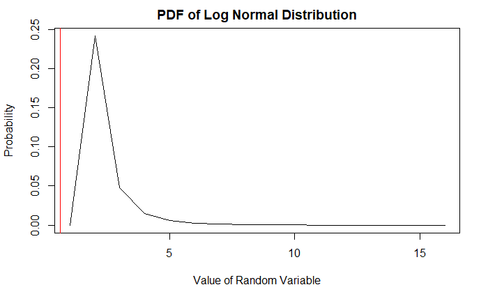

```r
abline(v = medianln, col = "black")
```

```r
#CDF
plot(plnorm(0:15, meanlog = -1, sdlog = 1), type = "l", xlab = "Value of Random Variable", ylab = "Probability", main = "CDF of Log Normal Distribution")
abline(v = meanln, col = "red")
```

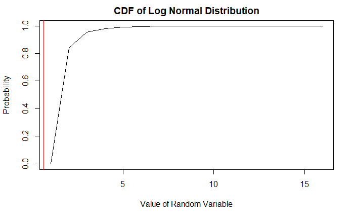

```r
abline(v = medianln, col = "black")
```

```r
#PDF of log(X)
plot(dlnorm(0:15, meanlog = -1, sdlog = 1, log = TRUE), type = "l", xlab = "Value of Log of Random Variable", ylab = "Probability", main = "PDF of Log Normal Distribution")
abline(v = logmeanln, col = "red")
```

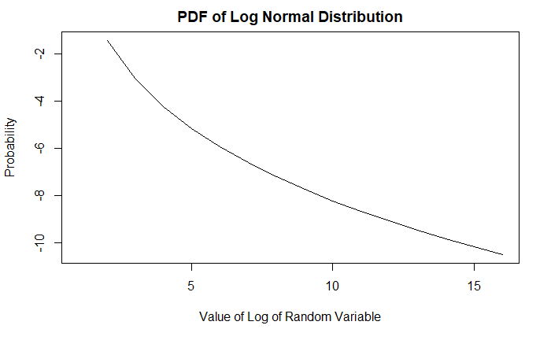

```r
abline(v = logmedianln, col = "black")
```

```r
#CDF of log(X)
plot(plnorm(0:15, meanlog = -1, sdlog = 1, log = TRUE), type = "l", xlab = "Value of Log of Random Variable", ylab = "Probability", main = "CDF of Log Normal Distribution")
abline(v = logmeanln, col = "red")
```

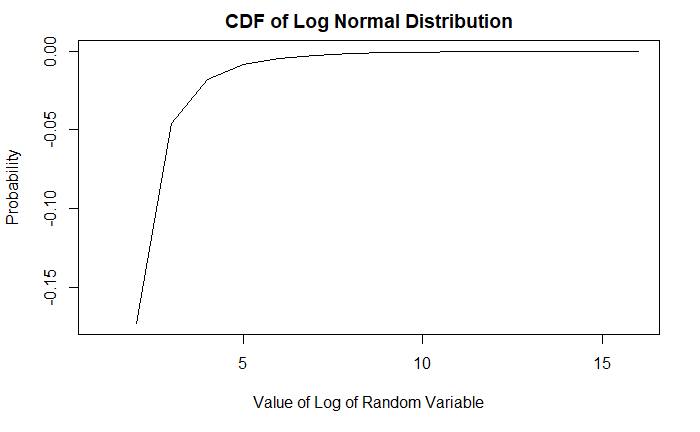

```r
abline(v = logmedianln, col = "black")
```

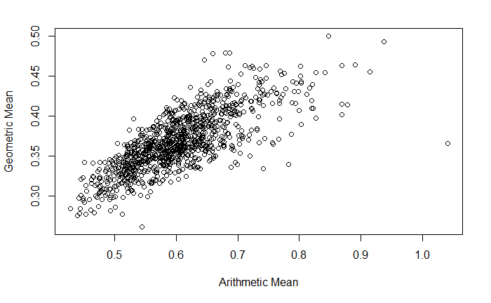

```r
mln = c()
gmln = c()
for (i in 1:1000)
{
  ln <- rlnorm(1:100, meanlog = -1, sdlog = 1)
  m <- mean(ln)
  gm <- exp(mean(log(ln)))
  mln[i] <- m
  gmln[i] <- gm
}

plot(mln, gmln, xlab = "Arithmetic Mean", ylab = "Geometric Mean")
```

Distribution 3 X∼UNIFORM(0,12)

```r
plot(dunif(0:50, min = 0, max = 12), type = "l")
plot(punif(0:50, min = 0, max = 12), type = "l")
plot(log(dunif(0:50, min = 0, max = 12)), type = "l")
plot(log(punif(0:50, min = 0, max = 12)), type = "l")
```

[output not shown]

```r
#dgamma(1:15, shape = 3, scale = 1)

# mean(dgamma(1:15, shape = 3, scale = 1))
# mean(dgamma(1:150, shape = 3, scale = 1))
# plot(dgamma(1:100, shape = 3, scale = 1), type = "l")

mean(rgamma(1:15000, shape = 3, scale = 1))
```

[output not shown]